# Make Countries Move

Amanda Miriam

14/3/2025

# Explore global development with R

In this exercise, you will load a filtered `gapminder` dataset - with a subset of data on global development from 1952 - 2007 in increments of 5 years - to capture the period between the Second World War and the Global Financial Crisis.

**Your task: Explore the data and visualise it in both static and animated ways, providing answers and solutions to 7 questions/tasks within this script.**

- **Submit to Github this script with solutions and its knitted version.**
- **Submit to Brightspace a document with the (1) URL of this script and its knitted version in Github (2) answer of 250 words and a (3) visualisation of the Final Question**

## Get the necessary packages

First, start with installing and activating the relevant packages `tidyverse`, `gganimate`, and `gapminder` if you do not have them already. *Pay attention to what warning messages you get when installing `gganimate`, as your computer might need other packages than `gifski` and `av`*

```r
# install.packages("gganimate")
# install.packages("gifski")
# install.packages("av")
# install.packages("gapminder")
library(tidyverse)
library(gganimate)
library(gifski)
library(av)
library(gapminder)
```

## Look at the data and tackle the tasks

First, see which specific years are actually represented in the dataset and what variables are being recorded for each country. Note that when you run the cell below, Rmarkdown will give you two results - one for each line - that you can flip between.

```r
str(gapminder)
```

```
## tibble [1,704 × 6] (S3: tbl_df/tbl/data.frame)
##  $ country  : Factor w/ 142 levels "Afghanistan",..: 1 1 1 1 1 1 1 1 1 1 ...
##  $ continent: Factor w/ 5 levels "Africa","Americas",..: 3 3 3 3 3 3 3 3 3 3 ...
##  $ year     : int [1:1704] 1952 1957 1962 1967 1972 1977 1982 1987 1992 1997 ...
##  $ lifeExp  : num [1:1704] 28.8 30.3 32 34 36.1 ...
##  $ pop      : int [1:1704] 8425333 9240934 10267083 11537966 13079460 14880372 12881816 13867957 16317921 22227415 ...
##  $ gdpPercap: num [1:1704] 779 821 853 836 740 ...
```

```r
unique(gapminder$year)
```

```
##  [1] 1952 1957 1962 1967 1972 1977 1982 1987 1992 1997 2002 2007
```

```r
head(gapminder)
```

```
## # A tibble: 6 × 6
##   country     continent  year lifeExp      pop gdpPercap
##   <fct>       <fct>     <int>   <dbl>    <int>     <dbl>
## 1 Afghanistan Asia       1952    28.8  8425333      779.
## 2 Afghanistan Asia       1957    30.3  9240934      821.
## 3 Afghanistan Asia       1962    32.0 10267083      853.
## 4 Afghanistan Asia       1967    34.0 11537966      836.
## 5 Afghanistan Asia       1972    36.1 13079460      740.
## 6 Afghanistan Asia       1977    38.4 14880372      786.
```

The dataset contains information on each country in the sampled year, its continent, life expectancy, population, and GDP per capita.

Let’s plot all the countries in 1952.

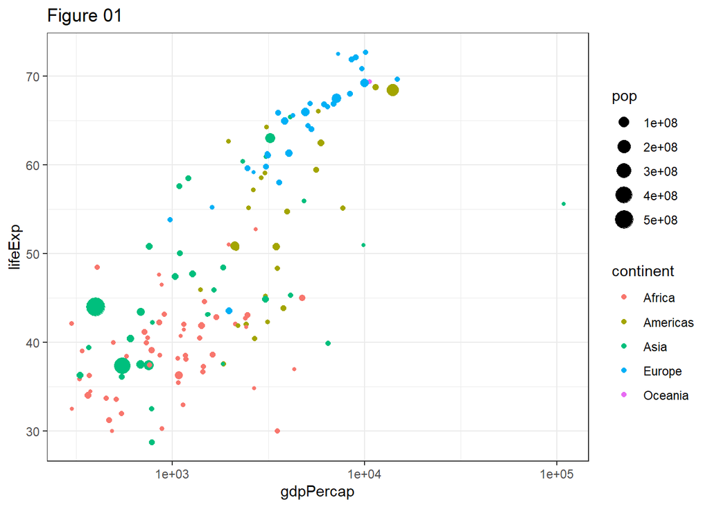

```r
theme_set(theme_bw())  # set theme to white background for better visibility

ggplot(subset(gapminder, year == 1952), aes(gdpPercap, lifeExp, size = pop)) +
  geom_point(aes(color=continent)) +
  scale_x_log10() +
  ggtitle("Figure 01")
```

```r
# Set option to disable scientific notation
options(scipen = 999)
```

We see an interesting spread with an outlier to the right. Explore who it is so you can answer question 2 below!

…

```r
# To find out which country is the outlier, I used this code from chatgpt
highest_gdp_country <- subset(gapminder, year == 1952)[which.max(subset(gapminder, year == 1952)$gdpPercap), ]
highest_gdp_country
```

```
## # A tibble: 1 × 6
##   country continent  year lifeExp    pop gdpPercap
##   <fct>   <fct>     <int>   <dbl>  <int>     <dbl>
## 1 Kuwait  Asia       1952    55.6 160000   108382.
```

```r
#Kuwait is the outlier
```

Next, you can generate a similar plot for 2007 and compare the differences

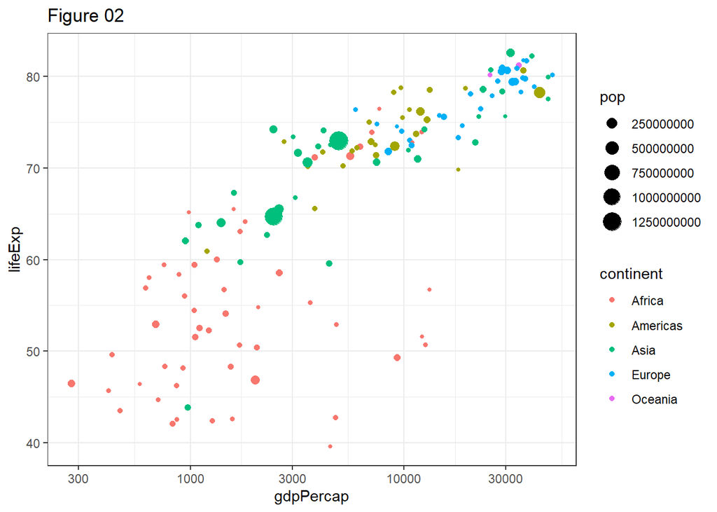

```r
ggplot(subset(gapminder, year == 2007), aes(gdpPercap, lifeExp, size = pop)) +
  geom_point(aes(color=continent)) +
  scale_x_log10() +
  ggtitle("Figure 02")
```

```r
options(scipen = 999)
```

…

### Questions for the static figures:

```r
# Load necessary libraries
library(dplyr)
library(gapminder)

# Find the five richest countries in 2007 based on GDP per capita
richest_countries <- gapminder %>%
  filter(year == 2007) %>%
  arrange(desc(gdpPercap)) %>%
  head(5)

# Print the five richest countries
print(richest_countries)
```

```
## # A tibble: 5 × 6
##   country       continent  year lifeExp       pop gdpPercap
##   <fct>         <fct>     <int>   <dbl>     <int>     <dbl>
## 1 Norway        Europe     2007    80.2   4627926    49357.
## 2 Kuwait        Asia       2007    77.6   2505559    47307.
## 3 Singapore     Asia       2007    80.0   4553009    47143.
## 4 United States Americas   2007    78.2 301139947    42952.
## 5 Ireland       Europe     2007    78.9   4109086    40676.
```

```r
# The five richest countries in 2007 are Norway, Kuwait, Singapore, United States and Ireland
```

## Make it move!

The comparison would be easier if we had the two graphs together, animated. We have a lovely tool in R to do this: the `gganimate` package. Beware that there may be other packages your operating system needs in order to glue interim images into an animation or video. Read the messages when installing the package.

Also, there are *two* ways of animating the gapminder ggplot.

### Option 1: Animate using transition_states()

The first step is to create the object-to-be-animated

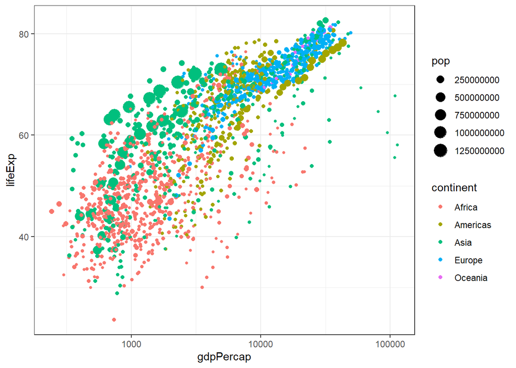

```r
anim <- ggplot(gapminder, aes(gdpPercap, lifeExp, size = pop)) +
  geom_point(aes(color=continent)) +
  scale_x_log10()  # convert x to log scale
anim
```

```r
# Set option to disable scientific notation
options(scipen = 999)
```

…

This plot collates all the points across time. The next step is to split it into years and animate it. This may take some time, depending on the processing power of your computer (and other things you are asking it to do). Beware that the animation might appear in the bottom right ‘Viewer’ pane, not in this rmd preview. You need to `knit` the document to get the visual inside an html file.

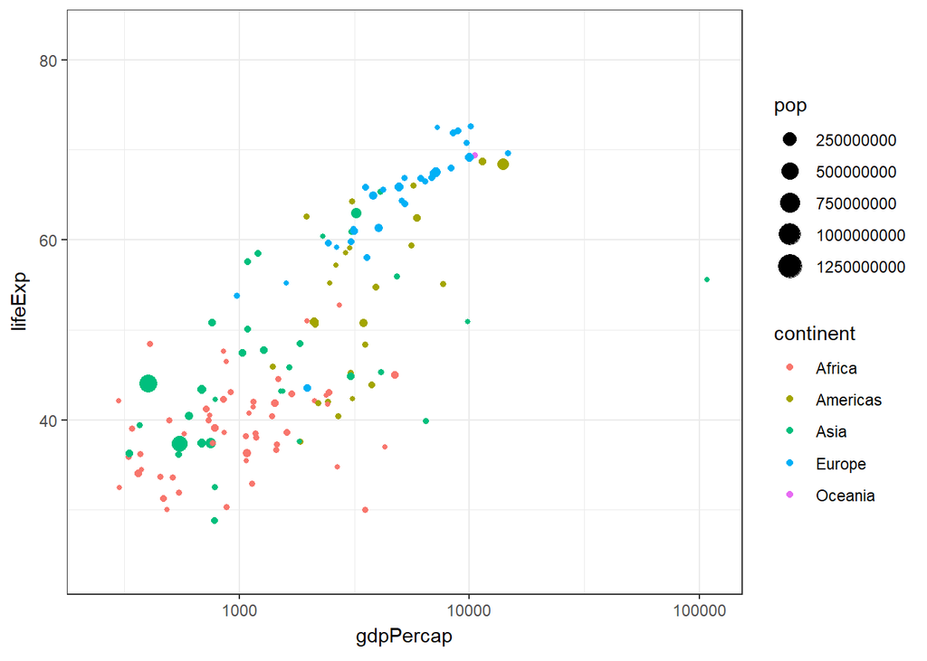

```r
anim + transition_states(year,
                      transition_length = 1,
                      state_length = 1)
```

…

Notice how the animation moves jerkily, ‘jumping’ from one year to the next 12 times in total. This is a bit clunky, which is why it’s good we have another option.

### Option 2 Animate using transition_time()

This option smooths the transition between different ‘frames’, because it interpolates and adds transitional years where there are gaps in the timeseries data.

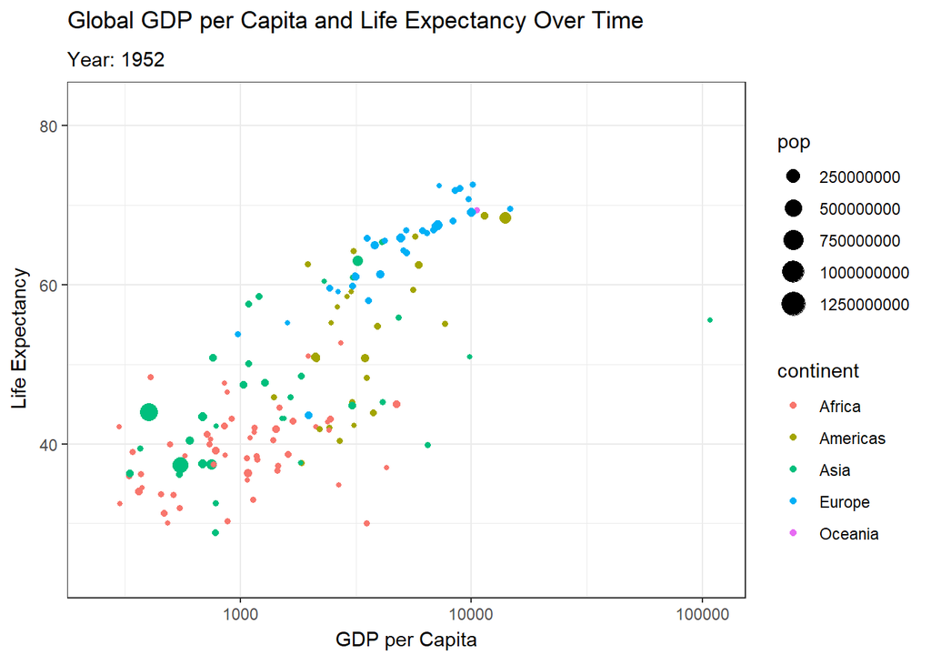

```r
anim2 <- ggplot(gapminder, aes(gdpPercap, lifeExp, size = pop)) +
  geom_point(aes(color=continent)) +
  scale_x_log10() + # convert x to log scale
  transition_time(year)+
  labs(
    title = 'Global GDP per Capita and Life Expectancy Over Time',  # Static title
    subtitle = 'Year: {frame_time}',  # Dynamic subtitle with year (updated for each frame)
    x = 'GDP per Capita',
    y = 'Life Expectancy'
  ) +
  transition_time(year) +  # Animate over the year
  ease_aes('linear')  # Linear transition
anim2
```

```r
options(scipen = 999)
```

The much smoother movement in Option 2 will be much more noticeable if you add a title to the chart, that will page through the years corresponding to each frame.

Now, choose one of the animation options and get it to work. You may need to troubleshoot your installation of `gganimate` and other packages

### Tasks for the animations:

5. *Can you add a title to one or both of the animations above that will change* *in sync with the animation?* *(**Hint**: search labeling for `transition_states()` and `transition_time()` functions respectively)*

I used chatpgt to add this code to the anim2, to make a title that changes and shows each year:

6. *Can you made the axes’ labels and units more readable? Consider expanding the abbreviated labels as well as the scientific notation in the legend and x axis to whole numbers. Also, differentiate the countries from different continents by color*

For the animation, I use option 2. I have eliminated scientific notions and gotten regular numbers instead. I have added a different color to each continent. I have changed the title, and made the year change with the animation. I have changed the titles on the y and x axes, so that they are easier to read

### Final Question

7. **Is the world a better place today than it was in the year you were born?** *Answer this question using the gapminder data. Define better either as more prosperous, more free, more healthy, or suggest another measure that you can get from gapminder. Submit a 250 word answer with an illustration to Brightspace. Include a URL in your Brightspace submission that links to the coded solutions in Github. [Hint: if you wish to have more data than is in the filtered gapminder, you can load either the `gapminder_unfiltered` dataset or download more historical data at https://www.gapminder.org/data/ ]*

animation 2002 to 2007:

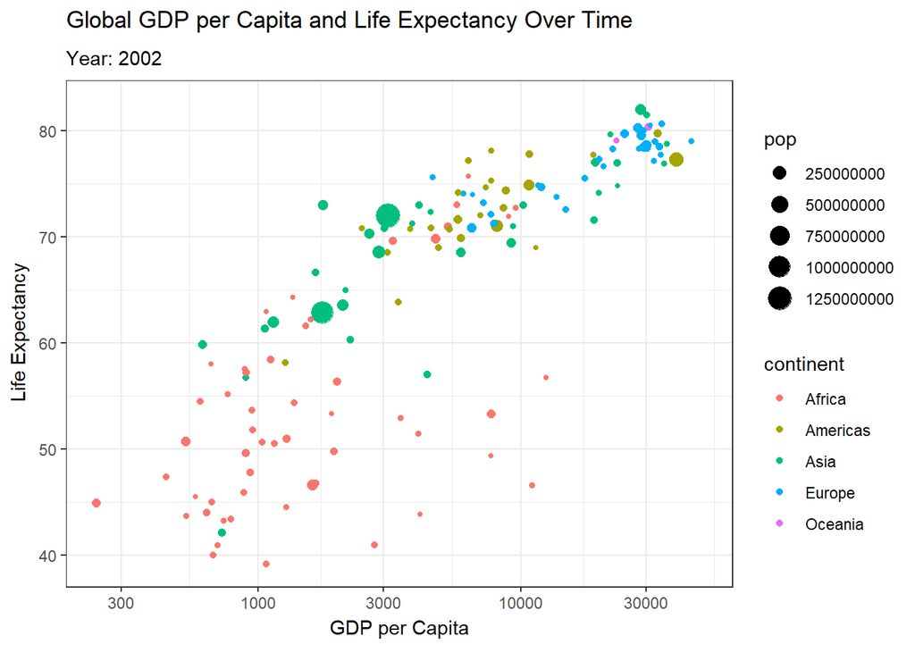

```r
library(ggplot2)
library(gganimate)
library(dplyr)

# Filter for years 2002 to 2007
gapminder_filtered <- gapminder %>%
  filter(year >= 2002 & year <= 2007)

# Create the animated plot
anim0207 <- ggplot(gapminder_filtered, aes(gdpPercap, lifeExp, size = pop)) +
  geom_point(aes(color = continent)) +
  scale_x_log10() +  # Convert x-axis to log scale
  transition_time(year) +  # Animate over the years 2002-2007
  labs(
    title = 'Global GDP per Capita and Life Expectancy Over Time',
    subtitle = 'Year: {frame_time}',  # Dynamic subtitle showing the year
    x = 'GDP per Capita',
    y = 'Life Expectancy'
  ) +
  ease_aes('linear')  # Smooth linear transition
anim0207
```

Plot from 2002 and 2007:

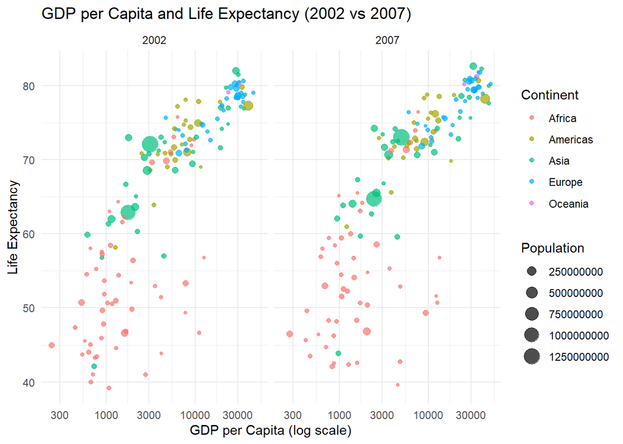

```r
library(ggplot2)
library(dplyr)

# Filter dataset for 2002 and 2007
gapminder_filtered <- gapminder %>%
  filter(year %in% c(2002, 2007))

# Create the plot
ggplot(gapminder_filtered, aes(x = gdpPercap, y = lifeExp, size = pop, color = continent)) +
  geom_point(alpha = 0.7) +  # Semi-transparent points
  scale_x_log10() +  # Log scale for GDP per capita
  facet_wrap(~year) +  # Create separate panels for 2002 and 2007
  labs(
    title = "GDP per Capita and Life Expectancy (2002 vs 2007)",
    x = "GDP per Capita (log scale)",
    y = "Life Expectancy",
    color = "Continent",
    size = "Population"
  ) +
  theme_minimal()  # Clean theme
```

Bar plot for 2002 and 2007:

[output not shown]

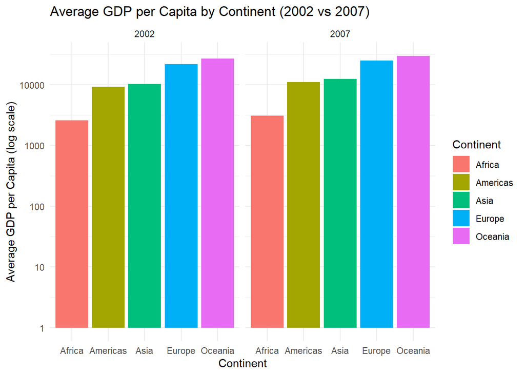

When defining whether the world is a better place today than in the year we were born, we use the year 2002. We define “better” by gdp per capita, which is defined as: “Average economic output per person in a country or region per year”. This indicates the wealth of the citizens in each country. The newest data from gapminder is from 2007, and we will therefore compare 2002 to 2007. We are aware that the information of 2007 is outdated in comparison to 2025, but due to trouble with uploading the newest data we have to work with what we have.

When we look at the comparison between 2002 and 2007, we can see minor improvements for all continents with similar rise in GDP per capita. The animation confirms this statement when showing the movement towards a higher GDP per. capita. You can see from both the graph and animation that Europe and Oceania have a significally higher GDP per capita than Africa both in 2002 and 2007. So there is a general incline for all, but the division between Europe, Oceania and Africa remains roughly the same. So has the world gotten any better in five years? Regarding to the wealth of the citizens, yes, a bit. But there is still inequality to be seen between Africa and Europe, Oceania.